# Wyjaśnialne Uczenie Maszynowe - Praca domowa 2

Anna Kozak

## Zbiór danych

Poniższa analiza została przygotowana na zbiorze danych opisujących sprzedaż domów (House Sales Prices). Poniżej lista zmiennych:

- `price` cena nieruchomości
- `bedrooms` liczba sypialni
- `bathrooms` liczba łazienek
- `sqft_living` powierzchnia użytkowa
- `sqft_lot` powierzchnia gruntu
- `floors` liczba pięter
- `waterfront` czy nad wodą
- `view` jakość widoku
- `condition` stan
- `grade` jakość konstrukcji i wykończenia
- `sqft_above` powierzchnia pięter
- `sqft_basement` powierzchnia piwnicy
- `yr_built` rok budowy
- `yr_renovated`rok remontu
- `zipcode` kod pocztowy
- `lat` szerokość geograficzna
- `long` długość geograficzna
- `sqft_living15` średnia powierzchnia użytkowa dla 15-Nearest Neighbors
- `sqft_lot15` średnia powierzchnia gruntu dla 15-Nearest Neighbors

Do modelowania ceny sprzedaży domu (`price`) wybrano zmienne takie jak `bedrooms`, `bathrooms`, `sqft_living`, `sqft_lot`, `floors`, `waterfront`, `view`, `condition`, `grade`, `sqft_above`, `sqft_basement`, `zipcode`, `lat`, `long`, `sqft_living15`, `sqft_lot15` oraz dwie dodatkowo utworzone zmienne `years` opisującą wiek nieruchomośći i `years_from_renovation` czyli lata od remontu nieruchomości.

## Analiza zmiennych

Poniżej wykres gęstości oraz boxplot opisujący zmienną `price`. Jak możemy zauważyć rozkład tej zmiennej jest skośny. Mediana ceny nieruchomości wynosi 450000. Mamy dużo obserwacji odstających.

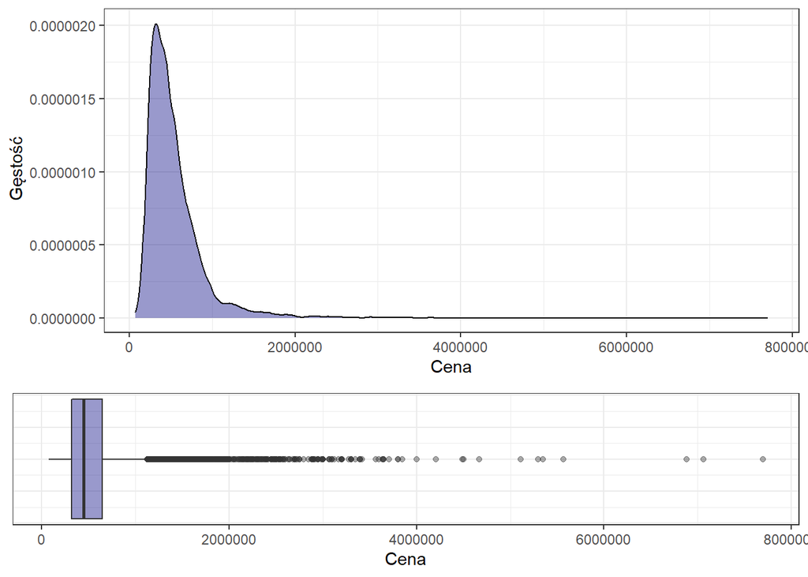

```r
p1 <- ggplot(dane, aes(x = price)) +
  theme_bw() +
  geom_density(fill = "navy", alpha = 0.4) +
  labs(x = "Cena", y = " Gęstość")

p2 <- ggplot(dane, aes(x = price)) +
  theme_bw() +
  geom_boxplot(fill = "navy", alpha = 0.4) +
  theme(axis.text.y = element_blank(), axis.ticks.y = element_blank()) +
  labs(x = "Cena")

grid.arrange(p1, p2, nrow = 2, heights = c(2, 1))
```

Dodatkowo poniżej zależności innych zmiennych od ceny nieruchmości.

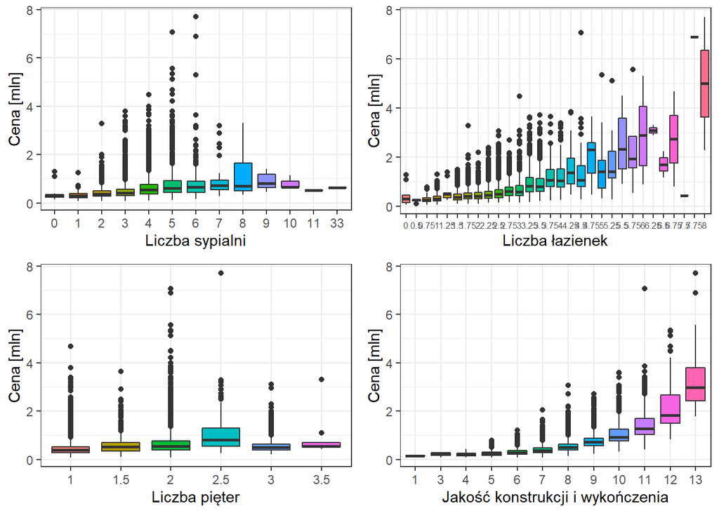

```r
p3 <- ggplot(dane, aes(x = as.factor(bedrooms), y = price/1000000, fill = as.factor(bedrooms))) +
  geom_boxplot() +
  theme_bw() +
  labs(x = "Liczba sypialni", y = "Cena [mln]", fill = "") +
  theme(legend.position = "none")

p4 <- ggplot(dane, aes(x = as.factor(bathrooms), y = price/1000000, fill = as.factor(bathrooms))) +
  geom_boxplot() +
  theme_bw() +
  labs(x = "Liczba łazienek", y = "Cena [mln]", fill = "") +
  theme(legend.position = "none", axis.text.x = element_text(size = 6))

p5 <- ggplot(dane, aes(x = as.factor(floors), y = price/1000000, fill = as.factor(floors))) +
  geom_boxplot() +
  theme_bw() +
  labs(x = "Liczba pięter", y = "Cena [mln]", fill = "") +
  theme(legend.position = "none")

p6 <- ggplot(dane, aes(x = as.factor(grade), y = price/1000000, fill = as.factor(grade))) +
  geom_boxplot() +
  theme_bw() +
  labs(x = "Jakość konstrukcji i wykończenia", y = "Cena [mln]", fill = "") +
  theme(legend.position = "none")

grid.arrange(p3, p4, p5, p6, nrow = 2, ncol = 2)
```

Zależność roku budowy nieruchomości od ceny. Ograniczenie do nieruchomości, których cena jest niższa niż 1 mln. Niewielki wzrost ceny dla obserwacji, które zostały zbudowane na początku XX wieku oraz początku XXI wieku.

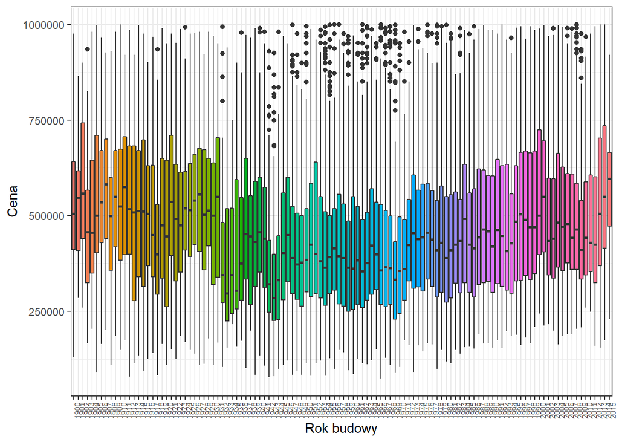

```r
ggplot(dane[dane$price < 1000000, ], aes(x = as.factor(yr_built), y = price, fill = as.factor(yr_built))) +
  geom_boxplot() +
  theme_bw() +
  labs(x = "Rok budowy", y = "Cena", fill = "") +
  theme(legend.position = "none") +
  theme(axis.text.x = element_text(angle = 90, hjust = 1, size = 6))
```

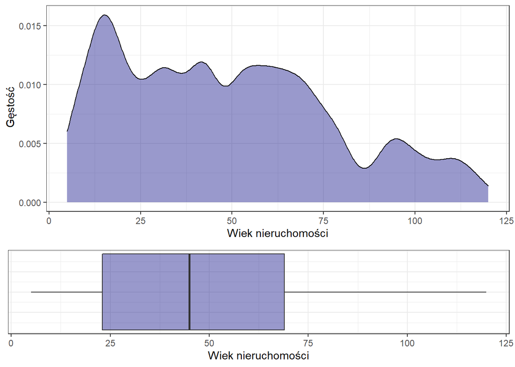

```r
p5 <- ggplot(dane, aes(x = years)) +
  geom_density(fill = "navy", alpha = 0.4) +
  theme_bw() +
  labs(x = "Wiek nieruchomości", y = " Gęstość")

p6 <- ggplot(dane, aes(x = years)) +
  theme_bw() +
  geom_boxplot(fill = "navy", alpha = 0.4) +
  theme(axis.text.y = element_blank(), axis.ticks.y = element_blank()) +
  labs(x = "Wiek nieruchomości")

grid.arrange(p5, p6, nrow = 2, heights = c(2, 1))
```

## Budowa modelu predykcyjnego (Ad 1)

Zbudowano model lasu losowego (`ranger`). Zmienna objaśniana to cena nieruchomości.

```r
## Modelowanie z mlr
library(mlr)
library(ranger)
## Dobór parametrów dla modelu random forest na podstawie metryki rmse
tsk <- makeRegrTask(data = dane_model, target = "price")
ps <- makeParamSet(
  makeIntegerParam("num.trees", lower = 50, upper = 1000),
  makeIntegerParam("mtry", lower = 1, upper = 4),
  makeIntegerLearnerParam("min.node.size", lower = 1, upper = 100))

ctrl <- makeTuneControlRandom(maxit = 100L)
rdesc <- makeResampleDesc("CV", iters = 3L)
res <- tuneParams("regr.ranger",
                 task = tsk,
                 resampling = rdesc,
                 par.set = ps,
                 control = ctrl,
                 measures = rmse)
lrn <- setHyperPars(makeLearner("regr.ranger"),
                   num.trees = res$x$num.trees,
                   mtry = res$x$mtry,
                   min.node.size = res$x$min.node.size)


## Trenowanie modelu
mod <- train(lrn, tsk)
```

### Predykcja dla obserwacji (Ad 2)

```r
task_pred = predict(mod, newdata = dane_model)
pred_values <- as.data.frame(task_pred)
```

## Wyjaśnienia

### Explainer

Budowanie obiektu `explain` dla modelu `mlr` przy użyciu funkcji `explain_mlr()` z pakietu `DALEXtra`.

```r
library(DALEX)
library(DALEXtra)

explain_mod <- DALEXtra::explain_mlr(model = mod, data = dane_model, y = dane_model$price)
```

```
## Preparation of a new explainer is initiated
##   -> model label       :  WrappedModel  (  default  )
##   -> data              :  21613  rows  19  cols
##   -> target variable   :  21613  values
##   -> data              :  A column identical to the target variable `y` has been found in the `data`.  (  WARNING  )
##   -> data              :  It is highly recommended to pass `data` without the target variable column
##   -> model_info        :  package mlr , ver. 2.17.0 , task regression (  default  )
##   -> predict function  :  yhat.WrappedModel  will be used (  default  )
##   -> predicted values  :  numerical, min =  126099.2 , mean =  540318 , max =  5689664
##   -> residual function :  difference between y and yhat (  default  )
##   -> residuals         :  numerical, min =  -1353531 , mean =  -229.8498 , max =  2010336
##   A new explainer has been created!
```

### Break Down oraz SHAP dla obserwacji (Ad 3)

```r
obs2 <- variable_attribution(explain_mod,
                 new_observation = dane_model[2, ],
                 type = "break_down")
plot(obs2)
```

[output not shown]

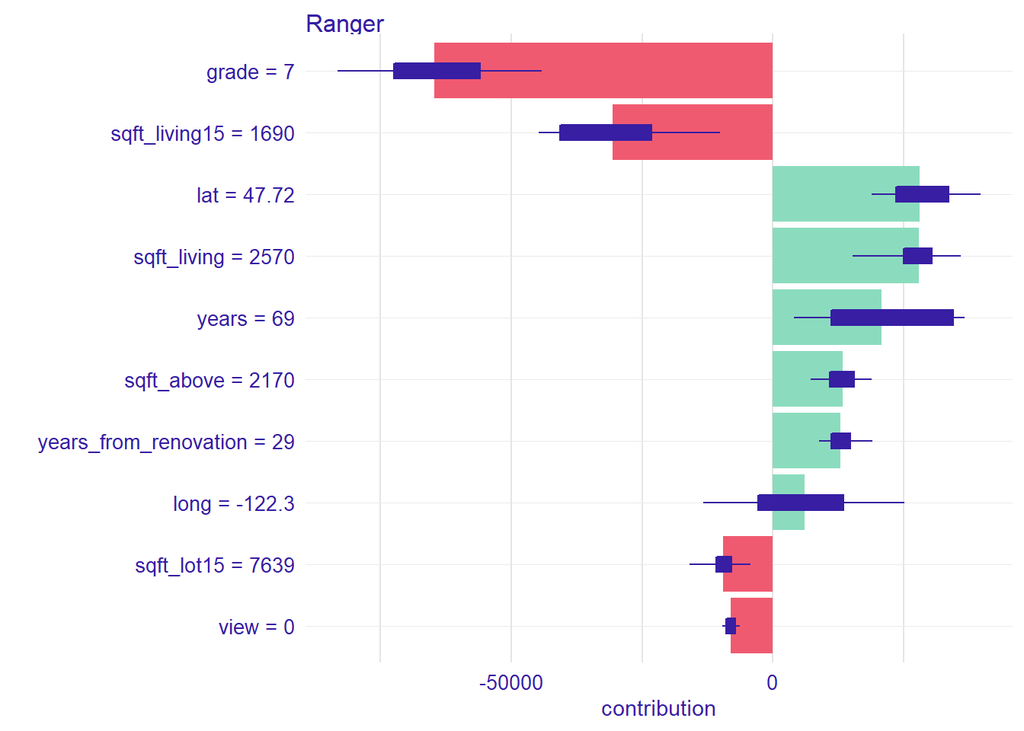

```r
shap_house <- variable_attribution(explain_mod,
                                   dane_model[2, ],
                                   type = "shap",
                                   B = 25)
plot(shap_house)
```

### Break Down dla dwóch obseracji, które mają inne zmienne istotne (Ad 4)

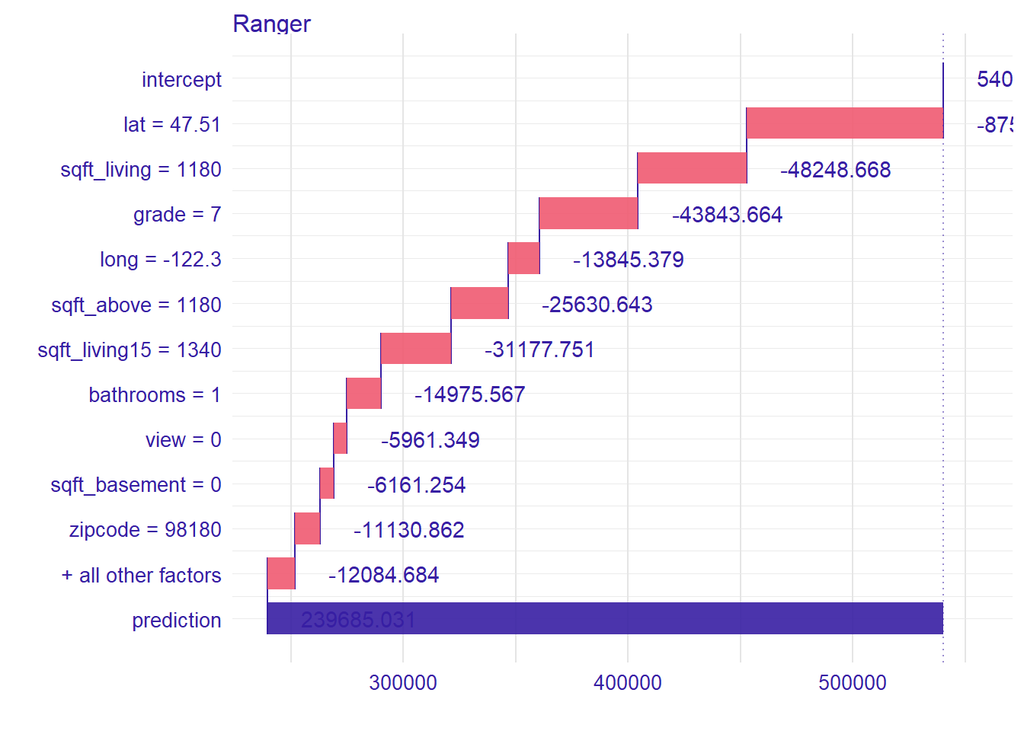

```r
plot(obs1)
```

```r
plot(obs2)
```

[output not shown]

### Break Down dla obserwacji, które mają różne efekty dla tej samej zmiennej

Dla tych dwóch obserwacji mamy inne efekt dla zmiennej `sqft_above`.

```r
obs3 <- variable_attribution(explain_mod,
                 new_observation = dane_model[3, ],
                 type = "break_down")
```

```r
plot(obs2)
```

[output not shown]

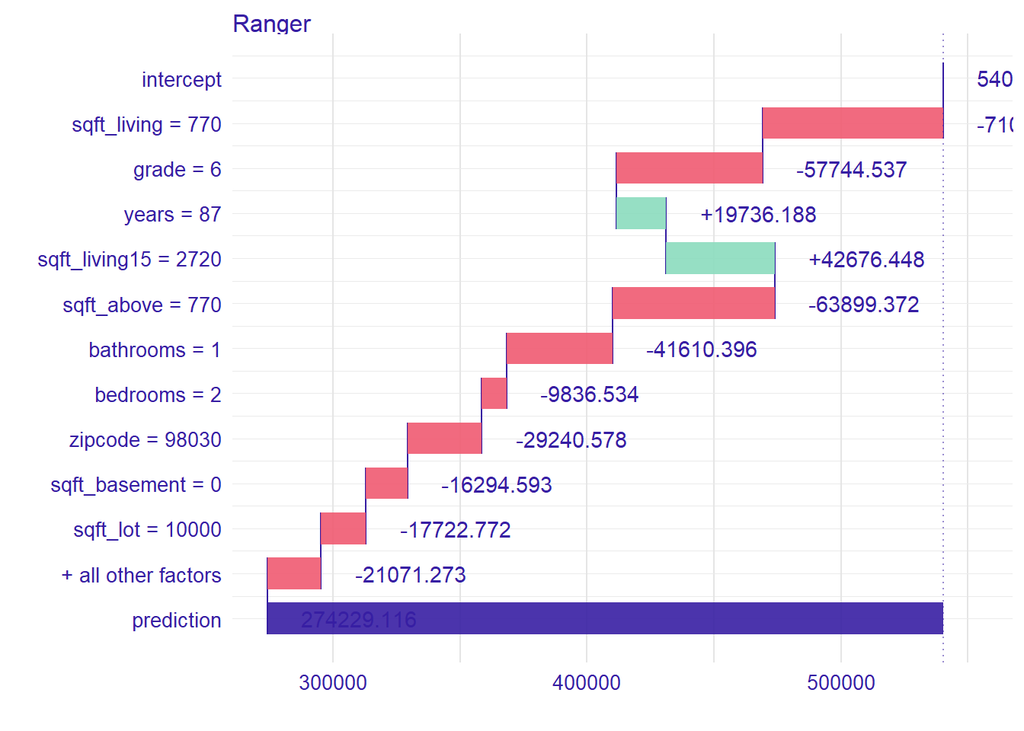

```r
plot(obs3)
```

### Model regresji liniowej oraz wykres Break Down dla modelu regresji oraz modelu lasu losowego (Ad 6)

```r
mod_lm <- lm(price ~ ., data = dane_model)

explain_mod_lm <- DALEX::explain(model = mod_lm, label = "Linear Regression")
```

```
## Preparation of a new explainer is initiated
##   -> model label       :  Linear Regression
##   -> data              :  21613  rows  19  cols  extracted from the model
##   -> target variable   :  not specified! (  WARNING  )
##   -> model_info        :  package stats , ver. 3.6.2 , task regression (  default  )
##   -> predict function  :  yhat.lm  will be used (  default  )
##   -> predicted values  :  numerical, min =  -531632.1 , mean =  540088.1 , max =  3366778
##   -> residual function :  difference between y and yhat (  default  )
##   A new explainer has been created!
```

```r
obs2_lm <- variable_attribution(explain_mod_lm,
                 new_observation = dane_model[2, ],
                 type = "break_down")

plot(obs2_lm)
```

```r
plot(obs2)
```

[output not shown]

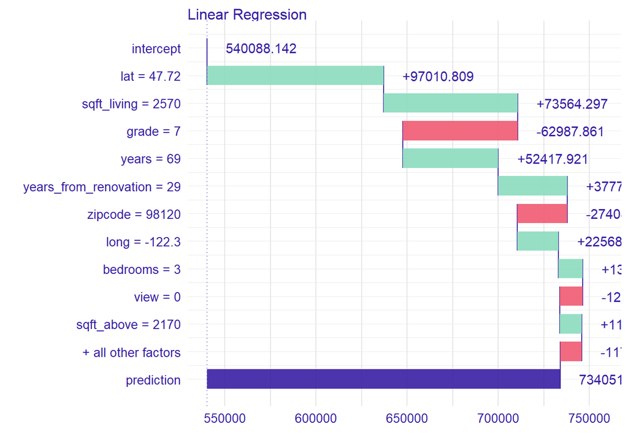

```r
plot(obs2_lm)
```

### Podsumowanie (Ad 7)

Wykresy Break Down służą do wyjaśnień lokalnych. Oznacza to, że wykorzystujemy je do badania wpływu zmiennych dla predycji wybranej obserwacji. Na podstawie powyższych wykresów możemy określić wpływ zmiennych na wyniki predykcji. Zauważamy, że dla różnych zmiennych mam inne zmienne istotne oraz to, że wpływy tych zmiennych mogą być różne. Dodatkowo zbudowano model regresji liniowej, wykresy Break Down w porówananiu z modelem lasu losowego dla tej samej obesrwacji pokazują różne zmienne istotne oraz różne ich wpływy.